# Monopoly and Public Policy

November 2, 2018

## Google sheets helpful?

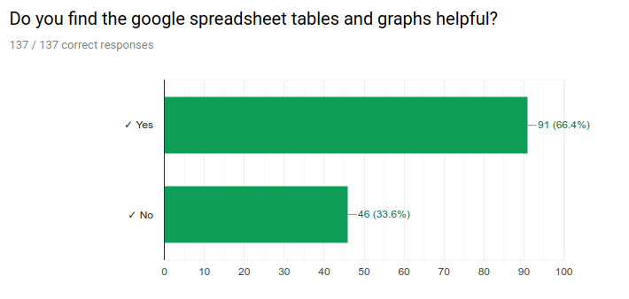

## The key to creating a monopoly

[figure not shown]

## Monopoly inefficiencies

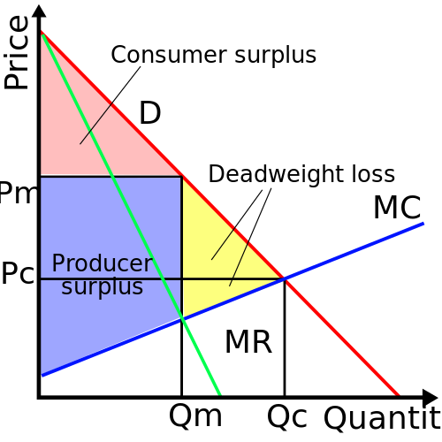

## Monopoly inefficiencies

- Higher price and lower quantity = deadweight loss
- But also, monopolists tend to stagnate, no longer innovating. This has a social cost.

## Natural Monopolies

- **Natural Monopoly** - An industry in which there are significant economies of scale due to high fixed costs, i.e. the *marginal cost* continues to decrease even for very high quantity produced.

For example, electrical production, water systems, roads, social network effects.

All benefit from initial investment and number of customers making it difficult for other firmst to enter the market, i.e. they create **barriers to entry**.

## Natural Monopolies

[video not shown]

[Natural monopoly](https://vimeo.com/298575803) from [Economics online](https://vimeo.com/user31487742) on [Vimeo](https://vimeo.com).

## Dealing with Monopolies

1. Anti-trust policy - legal frameworks to prevent or remove monopolies (here’s a [list of all anti-trust suits the U.S. government has filed](https://www.justice.gov/atr/antitrust-case-filings-alpha)). Generally this is through one of two things:
2. Break the company into multiple pieces (e.g. break AT&T into one company in each region of the U.S.).
3. Require licensing of infrastructure or a process (e.g. cell providers must license their bandwidth to other providers).
4. Set price limits - but it is difficult to find the right price.
5. In a natural monopoly, take public ownership - but then incentives become political and these can be poorly run.

## Monopoly political cartoons

[figure not shown]

Puck Magazine, August 1, 1883. Art by F. Graetz.

## Monopoly political cartoons

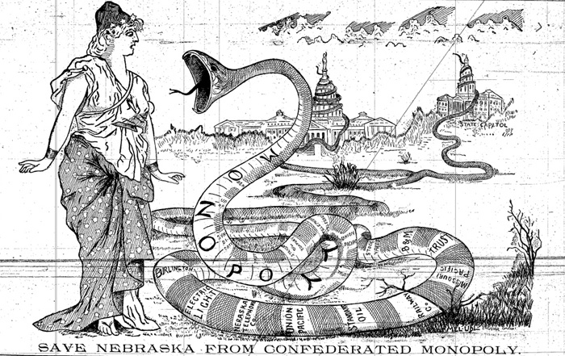

Omaha Evening Bee, November 3, 1894.

## Monopoly political cartoons

[figure not shown]

Puck Magazine, 1889.

## Monopoly political cartoons

[figure not shown]

Wall Street Journal, July 14, 2017. Art by Robert Neubecker.

## Wrapping Up

- Complete the [knowledge check](https://goo.gl/forms/Pi2DliCf7PioBjQV2) for today’s participation point.
- Please provide [feedback](https://goo.gl/forms/8SiOwdi19kN8cINJ3) on today’s lecture.